# Optimization Journey

## Convex optimization and linear programming

The problem we have just formulated is called a **linear program**, and the methods to solve it are subsumed as **linear programming** (although it has nothing to do with "programming" as we understand it today).

They are called *linear*, because both:

- they have a linear **objective function** $f(x) = c^\top x = c_0 x_0+ c_1 x_1 + \ldots + c_{n-1} x_{n-1}$ *and*
- the **constraints** $g(x) = A x \leq b$ **are linear.**

Problems like the one above are special cases of optimization (see Boyd & Vandenberghe):

- **Mathematical optimization** is the general case:

$$ \begin{array}{rl} \mbox{minimize the value of:} & f(x) \\ \mbox{subject to:} & g(x) \leq b, \end{array}$$

- for a **linear program**, the objective and constraints must be linear, i.e. the components (say, $h_i$) of $f$ and $g$ must satisfy:

$$h_i(\alpha x + \beta y) = \alpha h_i(x) + \beta h_i(y),$$

- whereas for a **convex optimization problem**, objective and constraints must satisfy:

$$h_i(\alpha x + \beta y) \leq \alpha h_i(x) + \beta h_i(y).$$

Linear programs and least-squares problems are special cases of convex optimization.

Linear programming problems **can be solved efficiently**, the algorithms used are the famous **simplex method** due to George Dantzig (which however is not polynomial), the **ellipsoid method** (which is polynomial, but much slower in practice), and **interior point methods**, which are widely used nowadays. See also Matousek & Gärtner for a gentle introduction.

To solve a linear programming problem, one uses typically a *solver*. This has the beauty of not having to program a solution to one's problem, instead it suffices to define the equations that describe one's problem.

There are free solvers and commercial ones, most of which are free for academic users. We will use `cvxpy`, which is a modelling language for convex optimization problems. It includes some solvers, but also is able to call external ones, see the list [here](https://www.cvxpy.org/tutorial/advanced/index.html#choosing-a-solver). That is, if you use `cvxpy` and also install a academic version of the commercial solver `gurobi`, then calling `solve()` in `cvxpy` may call an internal solver for "easy" problems and `gurobi` for "harder" problems (as we will see below).

Now lets develop the required formulas for our problem above. We have to minimize

$$ \min_{s,x} \sum_{i=0}^{m-1} s_i,$$

where in addition to the two original variables $x=(x_0,x_1)=(\mbox{intercept},\mbox{slope})$, we now also have the $s_i$ variables, one for each condition:

$$ \begin{matrix} \phantom{-}(a_i^\top x - b_i) & \leq & s_i & \mbox{and}\\ -(a_i^\top x - b_i) & \leq & s_i, & \\ \end{matrix} $$

if we sort that into variables (l.h.s.) and constants (r.h.s.) we get

$$ \begin{matrix} \phantom{-}a_i^\top x - s_i & \leq & \phantom{-}b_i & \mbox{and}\\ -a_i^\top x - s_i & \leq & -b_i, & \\ \end{matrix} $$

and if we define, as above, $A$ and $b$ as

$$ A = \begin{bmatrix}1&p_0\\ 1&p_1\\ \vdots & \vdots\\ 1&p_{m-1} \end{bmatrix}, b = \begin{bmatrix}q_0\\q_1\\ \vdots \\q_{m-1}\end{bmatrix} $$

then our linear program is:

$$ \begin{array}{rl} \mbox{minimize:} & \sum_i s_i \\ \mbox{subject to:} & \phantom{-}A x - s \leq b \\ & -A x - s \leq -b\end{array}$$

and if you check the Python program below, this is pretty much how we can express it in `cvxpy`. Instead of the sum, one can alternatively write

$$ \begin{array}{rl} \mbox{minimize:} & ||s||_1 \\ \mbox{subject to:} & \phantom{-}A x - s \leq b \\ & -A x - s \leq -b\end{array}$$

therefore, we *minimize the* $l_1$ *norm of* $s$.

```
intercept 2.003 slope 0.501
```

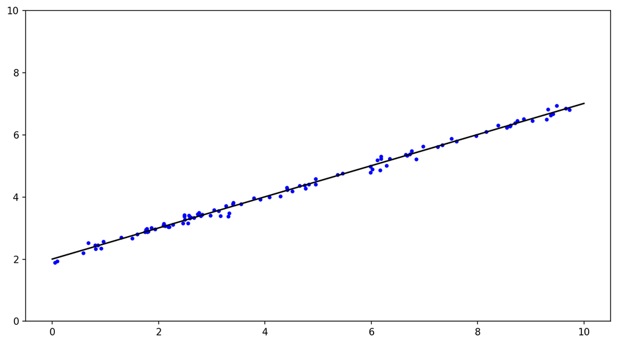

```python
import cvxpy as cp

def report_l1(inl, outl):
    both = np.concatenate((inl, outl))  # (m x 2) matrix of all point coordinates.

    # Estimate.
    m = both.shape[0]
    A = np.vstack((np.ones(m), both[:,0])).T
    b = both[:,1]
    # Setup problem for solver and solve.
    x, s = cp.Variable(2), cp.Variable(m)
    prob = cp.Problem(cp.Minimize(sum(s)),
                      [ A @ x - s <=  b,
                       -A @ x - s <= -b])
    prob.solve(verbose=False)  # Set to true to see solver working.

    # Print and plot results.
    intercept, slope = x.value
    print("intercept %.3f slope %.3f" % (intercept, slope))
    plt.plot(x_2d_vals, line(x_2d_vals), c="lightgray")
    plt.plot(inl[:,0], inl[:,1], "b.")
    plt.plot(outl[:,0], outl[:,1], "r.")
    plt.plot(x_2d_vals, slope*x_2d_vals+intercept, c="k")
    plt.ylim(0,10)

report_l1(inliers,np.empty((0,2)))
```

```
intercept 2.023 slope 0.494
```

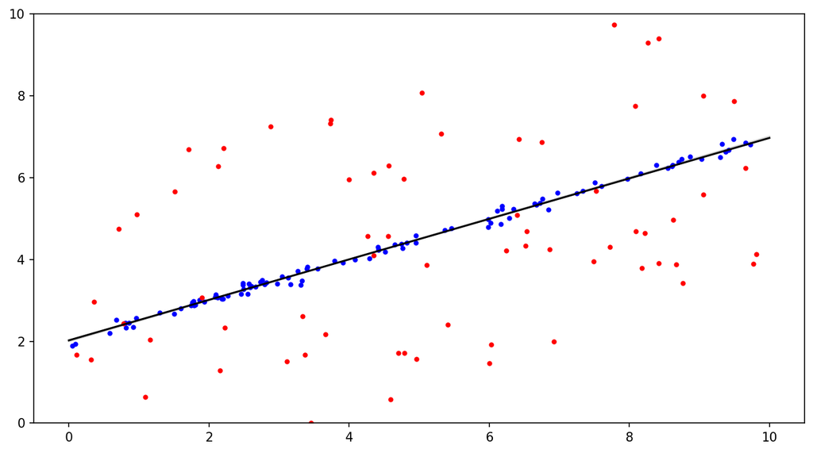

```python
report_l1(inliers, outliers)
```

```
intercept 2.034 slope 0.516
```

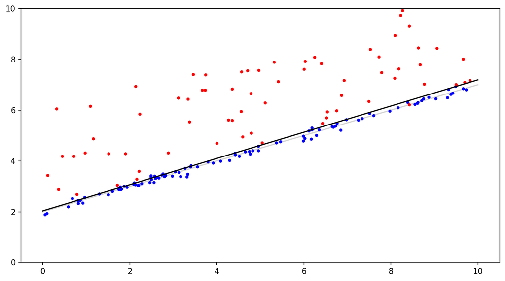

```python
report_l1(inliers, outliers_a)
```

However if we raise the number of outliers, this will break it, just as in the 1D case.

```
intercept 2.428 slope 0.613
```

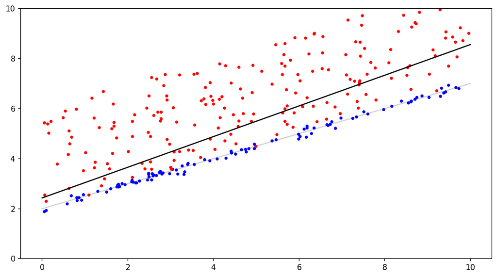

```python
n_2d_more_outliers = 200
more_outliers_x = rng.uniform(0,10,n_2d_more_outliers)
more_outliers_a_y = line(more_outliers_x) + rng.uniform(0,4,n_2d_more_outliers)
more_outliers_a = np.vstack((more_outliers_x, more_outliers_a_y)).T
report_l1(inliers, more_outliers_a)
```

## Maximum Consensus for the line

Remember for maximum consensus, we have to count $+1$ if an observation is within bounds $\pm\varepsilon$. We then have to maximize the count of inliers

$$x^* = \arg\max_x \sum_i \mathbb{1}\left( |a_i^\top x - b_i| \leq \varepsilon \right).$$

In the 1D case, we have expressed this already in an alternative way, namely as a minimization of the count of outliers. Define the $l_0$ (pseudo-) norm being *the number of non-zero elements*, i.e., $||s||_0$ is the count of elements of the vector $s$ which are non-zero. We now use $s$ as a *slack* variable, for which entry $s_i$ indicates the amount by which observation $i$ violates the $\leq\varepsilon$ constraint. Then, maximum consensus is the problem to

$$ \begin{array}{rl} \mbox{minimize:} & ||s||_0 \\ \mbox{subject to:} & | a_i^\top x - b_i | \leq \varepsilon + s_i \\ & s_i \geq 0.\end{array}$$

Thus, if observation $i$ is an inlier, it satisfies $| a_i^\top x - b_i | \leq \varepsilon$, and the slack $s_i$ will be zero. However, observation $i$ is an outlier, $s_i > 0$ must hold, and this increases $||s||_0$ by $1$. Since the behaviour of $||s||_0$ is hard to handle, one typically uses the **big-M** method to re-formulate this as follows:

$$ \begin{array}{rl} \mbox{minimize over $x\in\mathbb{R}^n$ and $z\in\{0,1\}^m$:} & \sum_i z_i \\ \mbox{subject to:} & | a_i^\top x - b_i | \leq \varepsilon + z_i\cdot M, \end{array}$$

where $M$ is a sufficiently large *(big)* constant, and the variables $z_i$ are binary. They switch on or off the "outlier status" of the $i$-th observation. If $z_i=0$, the constraint $| a_i^\top x - b_i | \leq \varepsilon$ must hold, and observation $i$ is an inlier. However, if $z_i=1$, $| a_i^\top x - b_i | \leq \varepsilon + M$ must hold, and since $M$ is very large, this is always satisfied.

Since the $z_i$ are required to be binary (or, they could also be from $\mathbb{Z}$, we left the world of *linear programming* and entered the world of **Integer Programming (IP)**. More accurately, since we have to optimize a mixture of variable types, $x\in\mathbb{R}^n$ *and* $z\in\{0,1\}^m$, this is a **Mixed Integer Program (MIP)**.

Going from $\mathbb{R}$ to $\{0,1\}$ or $\mathbb{Z}$ seems like a little variation, but it changes everything. In general, there are no efficient ways to solve IP and MIP problems -- they are NP-hard. I.e., in general, one has to search the solution space. Well-known methods are *branch-and-bound*, *cutting planes*, and *branch-and-cut*. These methods are employed by solvers.

Despite being hopeless in general, some IP/MIP are efficiently solvable, for others there are approximation algorithms (with guarantees) or efficient heuristics (without guarantees), see e.g. Conforti et al.. There are also links to combinatorial optimization, see Korte & Vygen. Approximation algorithms are discussed in Williamson & Shmoys.

Side note on big-M: Although mathematically elegant, the "big-M" method is troubled, because if $M$ is made too small, the results will be wrong, and if $M$ is too large, convergence is slow and numerical instabilities may occur. This can be solved using *Mixed Logical Programming*, so in some solvers, one can use so-called *indicator constraints* of the form: $s_i \Rightarrow cond$, "if $s_i$ is true, condition $cond$ must hold" as a replacement for the big-M formulation.

In the following, we write down the equations from above in `cvxpy` notation:

[output not shown]

[output cut: 41 more lines]

```
  Cover: 34
  MIR: 48
  StrongCG: 26
  Flow cover: 443
  Inf proof: 312
  Zero half: 77

Explored 272272 nodes (13100201 simplex iterations) in 120.45 seconds
Thread count was 8 (of 8 available processors)

Solution count 5: 197 199 227 ... 300

Optimal solution found (tolerance 1.00e-04)
Best objective 1.970000000000e+02, best bound 1.970000000000e+02, gap 0.0000%
intercept 2.058 slope 0.499
```

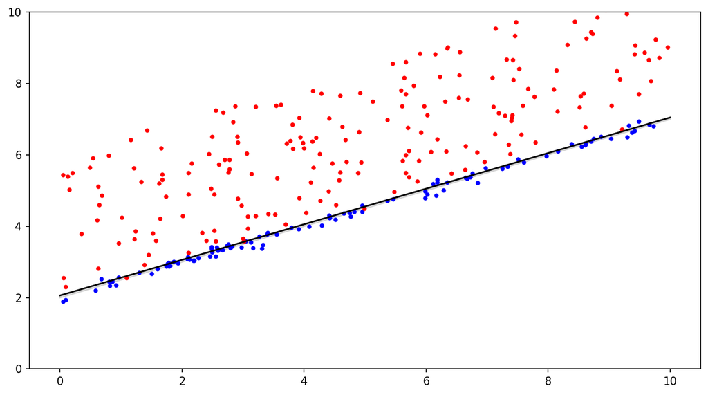

```python
def report_l0(inl, outl, eps, bigM):
    both = np.concatenate((inl, outl))  # (m x 2) matrix of all point coordinates.

    # Estimate
    m = both.shape[0]
    A = np.vstack((np.ones(m), both[:,0])).T
    b = both[:,1]
    x, z = cp.Variable(2), cp.Variable(m, boolean=True)  # Note: boolean=True.
    prob = cp.Problem(cp.Minimize(sum(z)),
                      [ A @ x - z * bigM <= eps + b,
                       -A @ x - z * bigM <= eps - b])
    prob.solve(verbose=True)  # Set to true to watch the solver working.

    # Print and plot results.
    intercept, slope = x.value
    print("intercept %.3f slope %.3f" % (intercept, slope))
    plt.plot(x_2d_vals, line(x_2d_vals), c="lightgray")
    plt.plot(inl[:,0], inl[:,1], "b.")
    plt.plot(outl[:,0], outl[:,1], "r.")
    plt.plot(x_2d_vals, slope*x_2d_vals+intercept, c="k")
    plt.ylim(0,10)

# Uncomment the next line to run (may take two minutes).
report_l0(inliers, more_outliers_a, eps=0.2, bigM=4.5)
```

Leaving the robust optimization topic!

# Convex optimization example: *model selection*, aka *shrinkage*

Now we used the problem of robust estimation to motivate least squares, least absolute deviation, and maximum consensus. To find a solution, we used an analytical solution (least squares), linear programming (least absolute deviation), and mixed integer programming (maximum consensus).

Although we motivated all this using the case of robust estimation, these techniques are important in their own right and are applied in numerous areas. This section is an example where you would encounter quadratic programming, the second-order sibling of linear programming.

The *model selection problem* occurs almost everywhere: if we want to explain data using a model, we should make the model sufficiently complex so that it is able to describe the "main characteristics" of the data. However, we should not make it overly complex, because then it will learn by heart the particular samples we have.

Here, we will illustrate this with fitting a polynomial to data. Intuitively, the "model complexity" is tied to the degree of the polynomial, or the number of monomials used to describe the polynomial (see below).

Methods for *model selection* are also termed *shrinkage methods*. See e.g. chap. 3.4 in Hastie et al.

We will look at four different methods to select our model:

- variation of the degree of the polynomial,
- ridge regression,
- the lasso,
- monomial selection via IP.

*Note: in the following, the intercept is not estimated. If we would estimate this as well, then we would have an additional "$1$" column in A, and $x_0$ would be the corresponding coefficient to be estimated. However then, in the ridge regression and lasso approaches below, one would have to replace $||x||_2$ and $||x||_1$ by $||x_{1:k-1}||_2$ and $||x_{1:k-1}||_1$, respectively, because $x_0$ depends on the choice of the coordinate system and it would make no sense to suppress large values. Equivalently, one can estimate the mean of $x$ and $b$ and work with centered inputs from there on, see Hastie et al., chap. 4.3.1 and 3.4.2.*

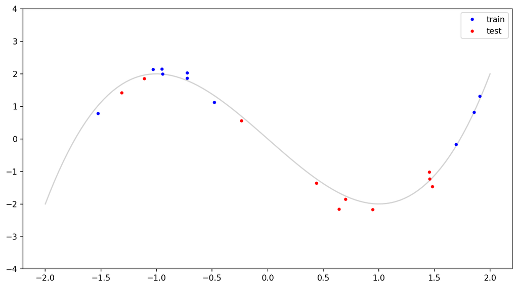

```python
# This function is our true model.
def model(x):
    return x**3 - 3*x

# Generate samples: uniform along x, and for each x, additive Gaussian "measurement" noise.
rng = np.random.default_rng(1234) # Restart.
x_2d_vals = np.linspace(-2,2,num=100)
n_2d_train, n_2d_test = 10, 10
data_x = rng.uniform(-2,2,n_2d_train+n_2d_test)
data_y = model(data_x) + rng.normal(0,0.2,data_x.size)
data = np.vstack((data_x, data_y)).T
train = data[:n_2d_train,:]
test  = data[n_2d_train:,:]

plt.plot(x_2d_vals, model(x_2d_vals), c="lightgray")
plt.plot(train[:,0], train[:,1], "b.", label="train")
plt.plot(test[:,0], test[:,1], "r.", label="test")
plt.legend()
ylim=(-4,4)
plt.ylim(ylim);
```

## Finding a suitable model via degree variation

As above, we use least-squares to find the parameters of the polynomial

$$x^* = \arg\min_{x}|| Ax - b ||_2^2.$$

which leads to the well-known solution

$$x^* = (A^\top A)^{-1} A^\top b.$$

Varying the "model complexity" is done by changing the degree of the polynomial which means that our $x$ vector has more or less entries. For example, if the degree of the polynomial is $1$, $x$ is a scalar, and $A$ has only one column.

```
coefficients = [  734.42723383  3297.85813648  3839.70968397 -1524.38842871
 -4420.2883595   -328.96155179  1694.34029152   172.30394681
  -234.13894108]
```

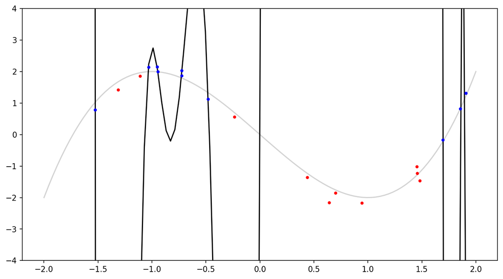

```python
# Powers of polynomials used for the fit: x**1, x**2,...
powers = range(1,10)

# The A matrix, each column is a x^i of the x coordinates.
A = np.vstack(tuple([train[:,0]**p for p in powers])).T
A_test = np.vstack(tuple([test[:,0]**p for p in powers])).T

# This is the least squares estimate.
coeff = np.linalg.pinv(A) @ train[:,1]
print("coefficients =", coeff)

# Plot result. Helper matrix M is like A, but for "all" x values.
M = np.vstack(tuple([x_2d_vals**p for p in powers])).T
plt.plot(x_2d_vals, model(x_2d_vals), c="lightgray")  # The model.
plt.plot(x_2d_vals, M@coeff, c="k")  # The estimate.
plt.plot(train[:,0], train[:,1], "b.")  # The training data used for the estimate.
plt.plot(test[:,0], test[:,1], "r.")  # The test data, just for visualization.
plt.ylim(ylim);
```

```python
# LS where degree can be set via slider.
import ipywidgets as ipyw
def plot_scan(max_columns):
    coeff = np.linalg.pinv(A[:,:max_columns]) @ train[:,1]
    plt.plot(x_2d_vals, model(x_2d_vals), c="lightgray")  # The model.
    plt.plot(x_2d_vals, M[:,:max_columns]@coeff, c="k")  # The estimate.
    plt.plot(train[:,0], train[:,1], "b.")  # The training data used for the estimate.
    plt.plot(test[:,0], test[:,1], "r.")  # The test data, just for visualization.
    plt.title(" | ".join("%.2f" % c for c in coeff))
    plt.ylim(ylim)
ipyw.interact(plot_scan, max_columns = ipyw.IntSlider(min=1, max=A.shape[1], value=A.shape[1]));
```

```
minimum test error at degree = 3
coefficients =  [-3.21259365 -0.05714723  1.10276638]
test error (MSE) = 0.0425
```

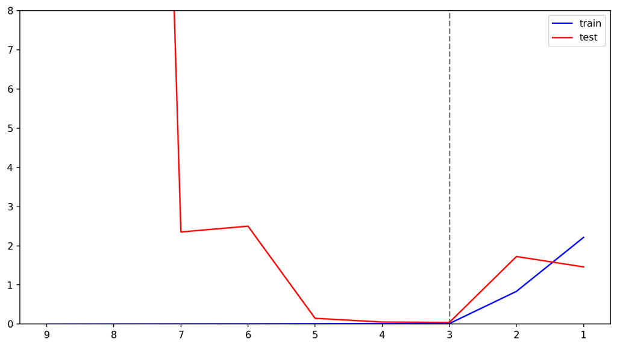

```python
# Plot training/test vs. degree.
errors = []
for max_columns in range(len(powers),0,-1):
    coeff = np.linalg.pinv(A[:,:max_columns]) @ train[:,1]  # LS for this degree.
    train_error = np.mean((A[:,:max_columns]@coeff - train[:,1])**2)  # MSE
    test_error = np.mean((A_test[:,:max_columns]@coeff - test[:,1])**2)
    errors.append((train_error, test_error))
degree_errors = np.array(errors)
degree_min_i = np.argmin(degree_errors[:,1])
print("minimum test error at degree = %d" % powers[A.shape[1]-1-degree_min_i])
print("coefficients = ", np.linalg.pinv(A[:,:A.shape[1]-degree_min_i]) @ train[:,1])
print("test error (MSE) = %.4f" % degree_errors[degree_min_i,1])

plt.axvline(x=degree_min_i, c="gray", ls="--")
plt.plot(degree_errors[:,0], c="blue", label="train")
plt.plot(degree_errors[:,1], c="red", label="test")
plt.xticks(range(len(powers)), range(len(powers),0,-1));
plt.legend()
train_test_ylim = (0,8)
plt.ylim(train_test_ylim);
```

## Finding a suitable model via ridge regression

Instead finding the solution for all different degrees (and dimensions of $A$), we "suppress" model complexity by forcing $x$ to be small (in terms of the squared $l_2$ norm). This is called *regularization*.

$$x^* = \arg\min_{x}|| Ax - b ||_2^2 + \lambda ||x||_2^2.$$

where $\lambda$ is a hyperparameter. Fortunately, this modification integrates nicely with standard least-squares, and the closed-form solution is

$$x^* = (A^\top A + \lambda I)^{-1} A^\top b,$$

so all there is to do is to add $\lambda$ to the main diagonal. This is a standard trick to remove singularities. Also, in surveying this is typically used as a soft constraint to "fix parameters by pseudo observation". And, in ML estimation, it can be nicely motivated by a prior distribution for x.

Varying the "model complexity" now means to play with $\lambda$. Intuitively, if it is 0, we obtain the standard least-squares solution, with the most complex model. If it grows, the model will become simpler.

```
[-0.51315762  4.40469954 -2.23459634 -5.86798511  2.4984694   2.87237632
 -1.15740307 -0.49792508  0.21426404]
```

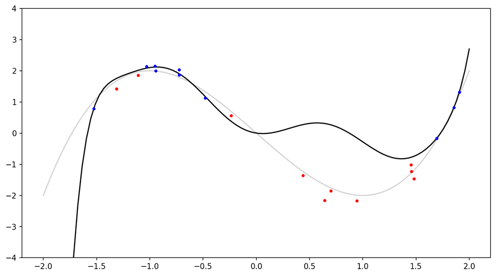

```python
# Ridge regression.
def ls_ridge(A, b, la):
    return np.linalg.solve(A.T @ A + np.eye(A.shape[1])*la, A.T @ b)

coeff = ls_ridge(A, train[:,1], 0.0001) # Set lambda here.
print(coeff)

# Plot result.
plt.plot(x_2d_vals, model(x_2d_vals), c="lightgray")
plt.plot(x_2d_vals, M@coeff, c="k")
plt.plot(train[:,0], train[:,1], "b.")
plt.plot(test[:,0], test[:,1], "r.")
plt.ylim(ylim);
```

```python
# Interactive: estimation vs. lambda.
lambda_logrange = (-11, 2)
def plot_scan(Lambda):
    coeff = ls_ridge(A, train[:,1], Lambda)
    plt.plot(x_2d_vals, model(x_2d_vals), c="lightgray")
    plt.plot(x_2d_vals, M@coeff, c="k")
    plt.plot(train[:,0], train[:,1], "b.")
    plt.plot(test[:,0], test[:,1], "r.")
    plt.title(" | ".join(("%.2f" % c) if abs(c) > 1e-2 else "****" for c in coeff))
    plt.ylim(ylim)
ipyw.interact(plot_scan, Lambda = ipyw.FloatLogSlider(
    min=lambda_logrange[0], max=lambda_logrange[1], value=lambda_logrange[0]));
```

```
minimum test error at lambda = 0.071
coefficients =  [-1.85923246  0.9682918  -0.19016454 -0.117939    0.36947685 -0.46032443
  0.10271592  0.14221997 -0.05182052]
test error (MSE) = 0.4783
```

```
(0.0, 10.0)
```

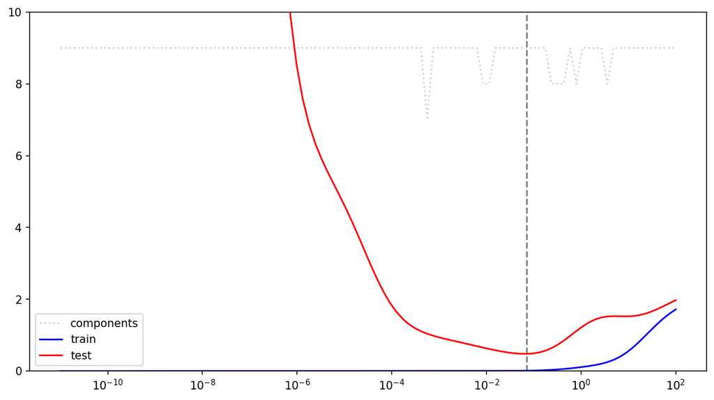

```python
# Train and test error vs. lambda.
lambdas = np.logspace(*lambda_logrange,100)
errors, components = [], []
for la in lambdas:
    coeff = ls_ridge(A, train[:,1], la)  # Ridge regression for this lambda.
    train_error = np.mean((A@coeff - train[:,1])**2)  # MSE
    test_error = np.mean((A_test@coeff - test[:,1])**2)
    errors.append((train_error, test_error))
    components.append((abs(coeff)>1e-2).sum())  # Also store the number of non-zero components.
ridge_errors = np.array(errors)
ridge_min_i = np.argmin(ridge_errors[:,1])
print("minimum test error at lambda = %.3f" % lambdas[ridge_min_i])
print("coefficients = ", ls_ridge(A, train[:,1], lambdas[ridge_min_i]))
print("test error (MSE) = %.4f" % ridge_errors[ridge_min_i,1])

plt.axvline(x=lambdas[ridge_min_i], c="gray", ls="--")
plt.plot(lambdas, components, ":", c="lightgray", label="components")
plt.plot(lambdas, ridge_errors[:,0], c="blue", label="train")
plt.plot(lambdas, ridge_errors[:,1], c="red", label="test")
plt.xscale("log")
plt.legend()
train_test_ylim = (0,10)
plt.ylim(train_test_ylim)
```

## Finding a suitable model via the lasso method

Now, we use the $l_2$ norm for the residuals, but the $l_1$ norm to "suppress" model complexity:

$$x^* = \arg\min_{x}|| Ax - b ||_2^2 + \lambda ||x||_1.$$

where as before, $\lambda$ is a hyperparameter. This does not integrate nicely in the least squares approach. What we obtain is a quadratic programming problem, which we will hand over to the solver. $\lambda$ plays the same role as before.

```python
# Lasso. Not linear programming, but rather quadratic programming (and convex optimization).
def loss_fn(A, b, x):
    return cp.norm2(A @ x - b)**2
def regularizer(x):
    return cp.norm1(x)
def objective_fn(A, b, x, Lambda):
    return loss_fn(A, b, x) + Lambda * regularizer(x)
def mse(A, b, x):
    return (1.0 / A.shape[0]) * loss_fn(A, b, x).value

def ls_lasso(A, b, Lambda):
    x = cp.Variable(A.shape[1])
    #lambd = cp.Parameter(nonneg=True)
    problem = cp.Problem(cp.Minimize(objective_fn(A, b, x, Lambda)))
    problem.solve(solver="GUROBI", verbose=False)
    return x.value
ls_lasso(A, train[:,1], 1.0)
```

```
array([-2.00310340e+00,  2.71582386e-01, -1.68314048e-09,  1.53682205e-08,
        8.21846790e-09,  6.92775446e-09,  1.32588725e-01, -2.63582201e-02,
       -1.02416801e-02])
```

```python
# Interactive: estimation vs. lambda.
def plot_scan(Lambda):
    coeff = ls_lasso(A, train[:,1], Lambda)
    plt.plot(x_2d_vals, model(x_2d_vals), c="lightgray")
    plt.plot(x_2d_vals, M@coeff, c="k")
    c2 = coeff.copy()
    c2[abs(c2)<1e-2]=0
    plt.plot(x_2d_vals, M@c2, "--", c="k")
    plt.plot(train[:,0], train[:,1], "b.")
    plt.plot(test[:,0], test[:,1], "r.")
    plt.title(" | ".join(("%.2f" % c) if abs(c) > 1e-2 else "****" for c in coeff))
    plt.ylim(ylim)
ipyw.interact(plot_scan, Lambda = ipyw.FloatLogSlider(
    min=lambda_logrange[0], max=lambda_logrange[1], value=lambda_logrange[0]));
```

```
minimum test error at lambda = 0.039
coefficients =  [-2.61724382e+00  5.96050780e-02  1.17055326e-06 -8.08586270e-07
  5.78830403e-01 -5.78176251e-02 -9.08084024e-02  1.46035057e-02
 -5.04656837e-06]
test error (MSE) = 0.0770
```

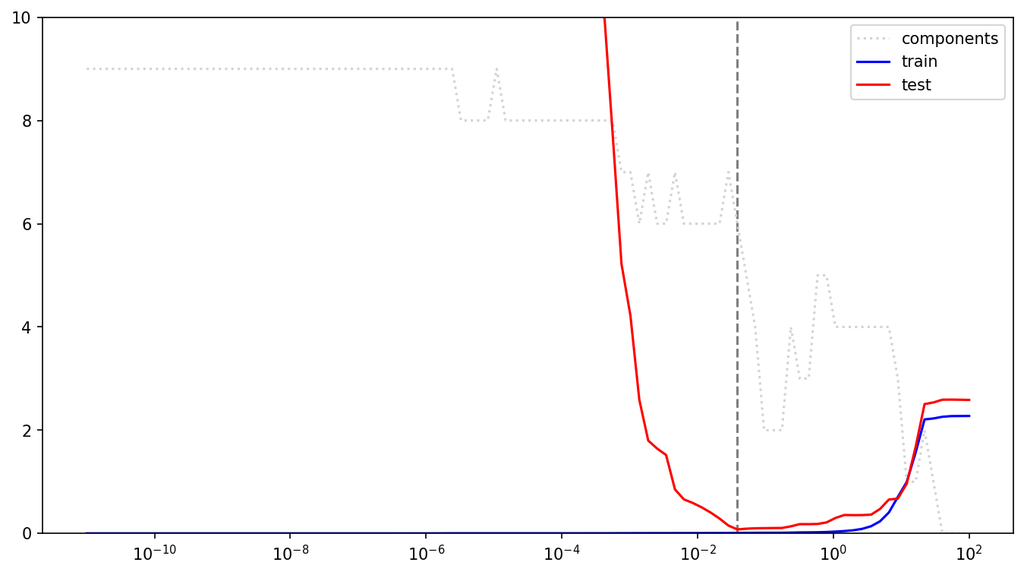

```python
# Train and test error vs. lambda.
errors, components = [], []
for la in lambdas:
    coeff = ls_lasso(A, train[:,1], la)  # Ridge regression for this lambda.
    train_error = np.mean((A@coeff - train[:,1])**2)  # MSE
    test_error = np.mean((A_test@coeff - test[:,1])**2)
    errors.append((train_error, test_error))
    components.append((abs(coeff)>1e-2).sum())  # Also store the number of non-zero components.

lasso_errors = np.array(errors)
lasso_min_i = np.argmin(lasso_errors[:,1])
print("minimum test error at lambda = %.3f" % lambdas[lasso_min_i])
print("coefficients = ", ls_lasso(A, train[:,1], lambdas[lasso_min_i]))
print("test error (MSE) = %.4f" % lasso_errors[lasso_min_i,1])

plt.axvline(x=lambdas[lasso_min_i], c="gray", ls="--")
plt.plot(lambdas, components, ":", c="lightgray", label="components")
plt.plot(lambdas, lasso_errors[:,0], c="blue", label="train")
plt.plot(lambdas, lasso_errors[:,1], c="red", label="test")
plt.xscale("log")
plt.legend()
plt.ylim(train_test_ylim);
```

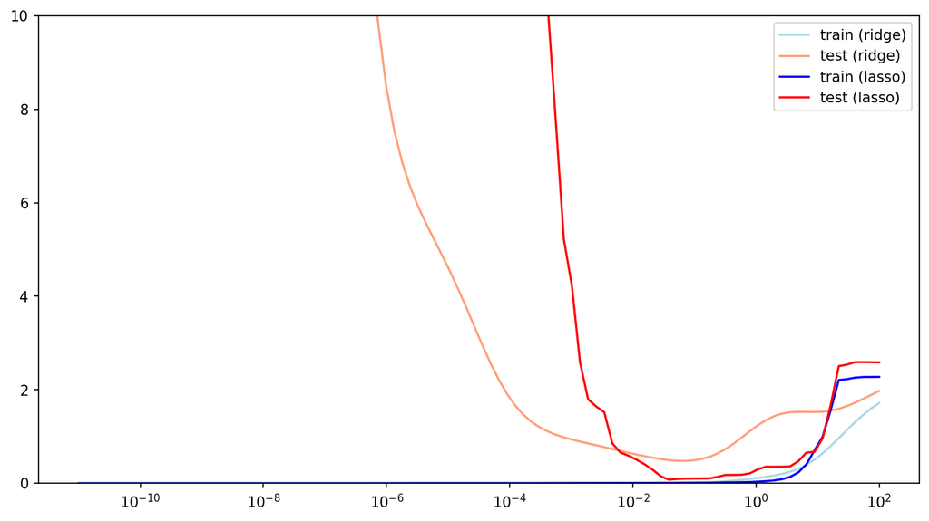

```python
# Comparison of test errors of ridge regression vs. lasso.
plt.plot(lambdas, ridge_errors[:,0], c="lightblue", label="train (ridge)")
plt.plot(lambdas, ridge_errors[:,1], c="lightsalmon", label="test (ridge)")
plt.plot(lambdas, lasso_errors[:,0], c="blue", label="train (lasso)")
plt.plot(lambdas, lasso_errors[:,1], c="red", label="test (lasso)")
plt.xscale("log")
plt.legend()
plt.ylim(train_test_ylim);
```

### Comparing the coefficients: ridge regression vs. lasso.

For ridge regression and lasso, we have a continuous parameter $\lambda$ to influence the model complexity. One can draw the components of $x$ vs. $\lambda$, sometimes called *regularization path*.

Comparing the results of ridge regression vs. lasso, one can see the tendency of lasso to obtain zero coefficients, or *sparse* results.

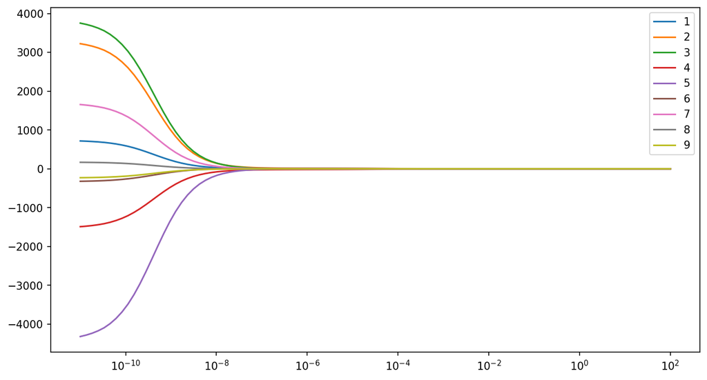

```python
# Ridge: coefficients vs. lambda.
ridge_results = np.array([ ls_ridge(A, train[:,1], la) for la in lambdas ])
for c in range(ridge_results.shape[1]):
    plt.plot(lambdas, ridge_results[:,c], label=powers[c])
plt.legend()
plt.xscale("log")
```

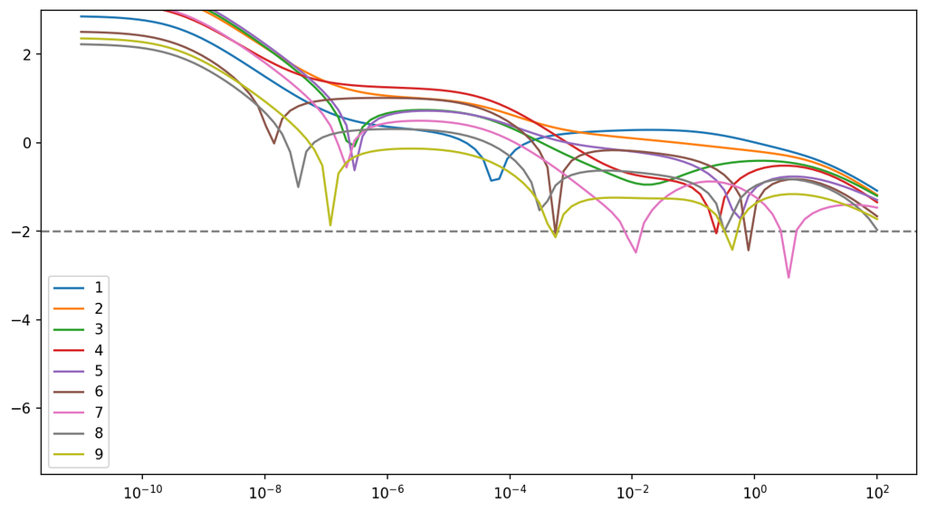

```python
# Ridge: coefficients vs. lambda.
plt.axhline(y=-2, c="gray", ls="--")
ridge_results = np.array([ ls_ridge(A, train[:,1], la) for la in lambdas ])
for c in range(ridge_results.shape[1]):
    plt.plot(lambdas, np.log10(np.abs(ridge_results[:,c])+1e-7), label=powers[c])
plt.legend()
ylim_log_coeff=(-7.5,3)
plt.ylim(ylim_log_coeff)
plt.xscale("log")
```

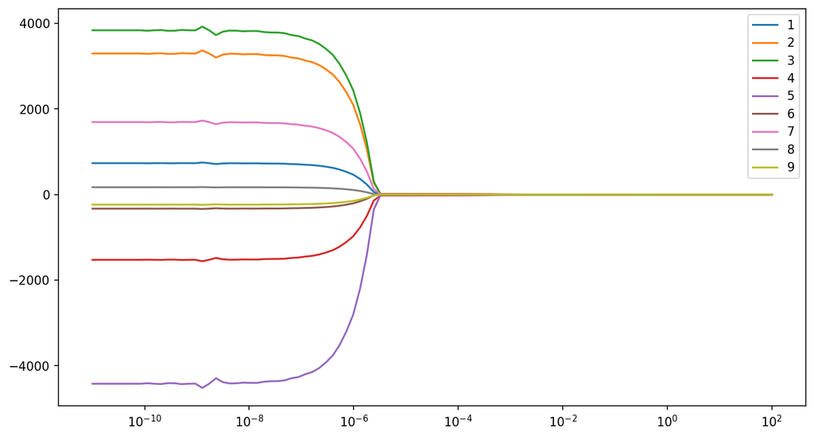

```python
# Lasso: coefficients vs. lambda.
lasso_results = np.array([ ls_lasso(A, train[:,1], la) for la in lambdas ])
for c in range(lasso_results.shape[1]):
    plt.plot(lambdas, lasso_results[:,c], label=powers[c])
plt.legend()
plt.xscale("log")
```

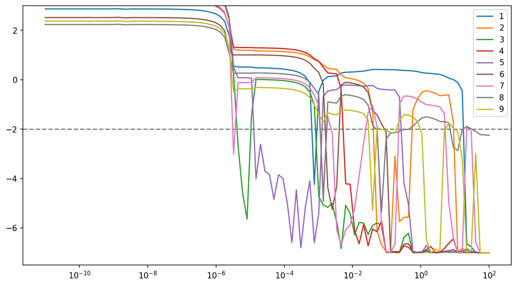

```python
# Lasso: coefficients vs. lambda.
plt.axhline(y=-2, c="gray", ls="--")
lasso_results = np.array([ ls_lasso(A, train[:,1], la) for la in lambdas ])
for c in range(lasso_results.shape[1]):
    plt.plot(lambdas, np.log10(np.abs(lasso_results[:,c])+1e-7), label=powers[c])
plt.legend()
plt.xscale("log")
plt.ylim(ylim_log_coeff);
```

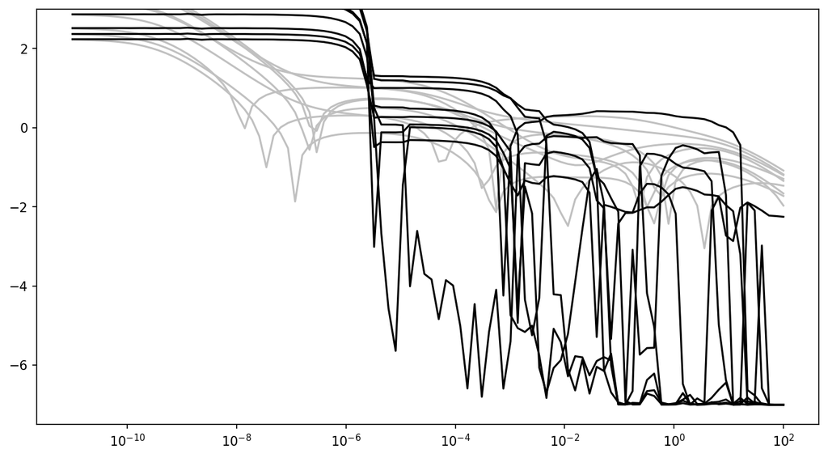

```python
# Both coefficient sets in one figure.
for c in range(ridge_results.shape[1]):
    plt.plot(lambdas, np.log10(np.abs(ridge_results[:,c])+1e-7), c="silver")
for c in range(lasso_results.shape[1]):
    plt.plot(lambdas, np.log10(np.abs(lasso_results[:,c])+1e-7), c="k")
plt.xscale("log")
plt.ylim(ylim_log_coeff);
```

## Monomial selection via IP

Let's come back to the first technique we looked at, *degree variation*. We selected the number of components $1\leq c\leq k$ and then computed the least squares estimate for a polynomial of degree $c$.

For example, in our case, the reference model is of degree $3$, and we obtained the best result using a polynomial of degree $3$. However, the reference model only contains the monomials $x$ and $x^3$, whereas our fit contains *all monomials up to degree* $3$, i.e., $x$, $x^2$, $x^3$.

So instead of requiring a maximum degree for the polynomial, we could require a maximum number of components (monomials). For example, if our reference model would contain only the odd monomials $x$, $x^3$, $x^5$, $x^7$, we could obtain a good fit using a polynomial with 4 components, but we would not achieve a good fit with a polynomial of degree 4, since this would contain $x$, $x^2$, $x^3$, $x^4$. Thus, we would include "useless" monomials $x^2$, $x^4$, while being unable to model the effects of $x^5$ and $x^7$.

The best fit with at most $c$ components can be elegantly formulated using integers (a mixed integer quadratic program):

$$ \begin{array}{rl} \mbox{minimize:} & ||Ax - b||_2^2 \\ \mbox{subject to:} & | x_i | \leq z_i\cdot M \\ & \sum_i z_i \leq c,\end{array}$$

$x_i\in\mathbb{R}$, $z_i\in \{0,1\}$, again using the "big-M" formulation. If $z_i$ is $0$, the component $x_i$ is forced to $0$ in the least squares estimation, otherwise, it is unconstrained. This can be directly formulated in `cvxpy`:

```python
# Compute solutions with 1,...,c components.
# If you encounter problems with this bigM constant, try to play with it. For me, this value
# worked on Linux, but not on Windows, a kind of worrying result. But after all, bigM
# is known for being numerically problematic. The solution would be to re-formulate it in terms
# of "indicator constraints".
bigM = 5000
k_comp_solutions = [ None ]
for c in range(1, A.shape[1]+1):
    x, z = cp.Variable(A.shape[1]), cp.Variable(A.shape[1], boolean=True)
    prob = cp.Problem(cp.Minimize(cp.norm2(A @ x - train[:,1])**2),
                      [-bigM*z <= x,
                       x <= bigM*z,
                       cp.sum(z) <= c ])
    prob.solve(verbose=False)
    k_comp_solutions.append(x.value)

# k component solutions via slider.
import ipywidgets as ipyw
def plot_scan(max_components):
    coeff = k_comp_solutions[max_components]
    plt.plot(x_2d_vals, model(x_2d_vals), c="lightgray")  # The model.
    plt.plot(x_2d_vals, M@coeff, c="k")  # The estimate.
    plt.plot(train[:,0], train[:,1], "b.")  # The training data used for the estimate.
    plt.plot(test[:,0], test[:,1], "r.")  # The test data, just for visualization.
    plt.title(" | ".join(("%.2f" % c) if abs(c) > 1e-2 else "****" for c in coeff))
    plt.ylim(ylim)
ipyw.interact(plot_scan, max_components = ipyw.IntSlider(min=1, max=A.shape[1], value=A.shape[1]));
```

```
minimum test error at #components = 2
coefficients =  [-3.09355964  0.          1.0415197   0.          0.          0.
  0.          0.          0.        ]
test error (MSE) = 0.0503
```

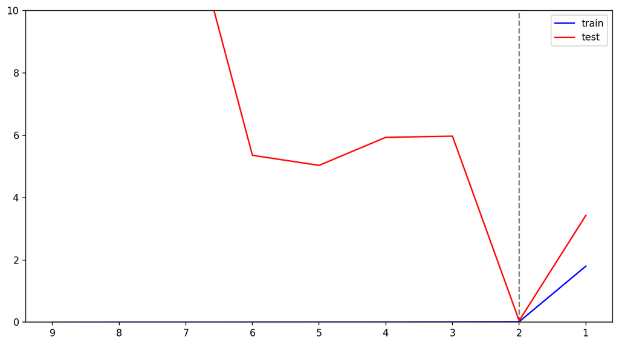

```python
# Plot training/test vs. number of components.
errors = []
for max_columns in range(1, A.shape[1]+1):
    coeff = k_comp_solutions[max_columns]
    train_error = np.mean((A@coeff - train[:,1])**2)  # MSE
    test_error = np.mean((A_test@coeff - test[:,1])**2)
    errors.append((train_error, test_error))
component_errors = np.array(errors)
best_components = np.argmin(component_errors[:,1])+1
print("minimum test error at #components = %d" % best_components)
print("coefficients = ", k_comp_solutions[best_components])
print("test error (MSE) = %.4f" % component_errors[best_components-1,1])

plt.axvline(x=A.shape[1]-best_components, c="gray", ls="--")
plt.plot(range(A.shape[1]-1,-1,-1), component_errors[:,0], c="blue", label="train")
plt.plot(range(A.shape[1]-1,-1,-1), component_errors[:,1], c="red", label="test")
plt.xticks(range(A.shape[1]), range(A.shape[1],0,-1))
plt.legend()
plt.ylim(train_test_ylim);
```

# A "typical" integer programming problem

Often, this is combinatorial optimization which can be expressed as an IP problem. Problems like:

- assignment problem (connect taxi drivers to customers)
- transportation/ transshipment problem
- knapsack problem
- bin packing problem
- cutting stock problem
- ...

But also in Geoinformatics:

- generalization
- label placement
- maximum a posteriori estimation in case of discrete random variables (see Chap. 13.5, *MAP as a linear optimization problem* in Koller & Friedman).

Here we will pick the following one:

## The uncapacitated facility location problem

We have clients $D$ (demand) and tentative outlet locations $F$ (facilities). If client $j$ goes to outlet $i$, this is associated with a cost $c_{ij}$, here we will use the Euclidean distance. So the client will always go to the closest outlet. If we want happy clients, we would open up as many outlets as possible (i.e. at each tentative location). However, to open an outlet up, we have to build it, so there is a one-time fixed cost $f_i$ to open outlet $i$. Now the goal is to minimize the total cost.

Formulated as an IP problem, we have the variables:

- $y_i$ which are binary variables telling if outlet $i$ is opened up ($1$) or not ($0$).
- $x_{ij}$ which are binary variables telling if customer $j$ goes to outlet $i$.

Then, the optimization problem is:

$$ \begin{array}{rlll} \mbox{minimize:} & \sum_i f_i y_i + \sum_{ij} c_{ij} x_{ij}\\ \mbox{subject to:} & \sum_i x_{ij} = 1 & \forall j & \mbox{(each client goes to exactly one outlet)}\\ & x_{ij} \leq y_i & \forall i,j & \mbox{(a client can only go to an outlet that is open)}\\ & x_{ij}, y_i \in \{0,1\}. \end{array}$$

This is a typical IP formulation: the binary variables are used as switches.

The *uncapacitated facility location problem* is a very well researched problem (see Korte & Vygen, chap. 22.1, and Williamson & Shmoys).

```python
from scipy.spatial import cKDTree
from matplotlib.collections import LineCollection
rng = np.random.default_rng(12345) # Restart.
n_factories = 40
n_demands = 80
factory_locations, demand_locations = rng.uniform(0,1,(n_factories, 2)), rng.uniform(0,1,(n_demands, 2))

# Random factory costs.
factory_max_cost = 20
factory_costs_1 = rng.uniform(0,factory_max_cost,n_factories)
factory_costs_2 = factory_max_cost - factory_costs_1

def evaluate(f_cost = 0.5, radius = 0.1):
    # Setup possible pairs, according to max_radius.
    tree = cKDTree(factory_locations)
    close_factories = tree.query_ball_point(demand_locations, radius)
    edges = np.array([ (i,n) for i, cf in enumerate(close_factories) for n in cf ], dtype=int)
    incoming_indices, j = [], 0
    for nlist in close_factories:
        l = len(nlist)
        if l > 0:
            incoming_indices.append((j,j+l))
            j += l

    # Compute edge costs, use Euclidean distance.
    edge_costs = np.array([ np.linalg.norm(demand_locations[d]-factory_locations[f]) for d,f in edges ])

    # Factory costs are a linear combination of the two costs.
    factory_costs = (1.0-f_cost)*factory_costs_1 + f_cost*factory_costs_2

    # Solve problem.
    yi = cp.Variable(n_factories, boolean=True)
    xij = cp.Variable(len(edges), boolean=True)
    prob = cp.Problem(cp.Minimize(factory_costs.T @ yi + edge_costs @ xij),
                      [ cp.sum(xij[f:t]) == 1 for f,t in incoming_indices ] +
                      [ xij <= yi[edges[:,1]] ])

    prob.solve(verbose=False)

    # Plot all possible edges.
    line_coll_data = np.array([ [tuple(demand_locations[d]), tuple(factory_locations[f])] for d, f in edges ])
    fig, ax = plt.subplots()
    ax.add_collection(LineCollection(line_coll_data, colors="gainsboro", zorder=0))
    ax.add_collection(LineCollection(line_coll_data[xij.value > 0], colors="blue", zorder=1))
    # Plot factory and demand locations.
    plt.scatter(demand_locations[:,0], demand_locations[:,1], c="white", edgecolors="k", s=50)
    plt.scatter(factory_locations[:,0], factory_locations[:,1], c=factory_costs,
                cmap="magma", vmin=0, vmax=factory_max_cost, s=100, marker="v")
    plt.scatter(factory_locations[:,0][yi.value>0], factory_locations[:,1][yi.value>0], c=factory_costs[yi.value>0],
                cmap="magma", vmin=0, vmax=factory_max_cost, s=300, marker="s", edgecolors="k")

ipyw.interact(evaluate, f_cost = ipyw.FloatSlider(min=0, max=1, step=0.05, value=0.5, continuous_update=False),
              radius = ipyw.FloatSlider(min=0.05, max=1.0, step=0.01, value=0.05, continuous_update=False));
```

# Bibliography

- Boyd & Vandenberghe: Convex Optimization, [free web download from the authors](https://web.stanford.edu/~boyd/cvxbook/).
- Conforti, Cornuejols, Zambelli: Integer Programming, [Springer](https://www.springer.com/gp/book/9783319110073).
- Hastie, Tibshirani, Friedman: The Elements of Statistical Learning, [free web download from the authors](https://web.stanford.edu/~hastie/ElemStatLearn/).
- Koller & Friedman: Probabilistic Graphical Models, [MIT Press](https://mitpress.ublish.com/book/probabilistic-graphical-models).
- Korte & Vygen: Combinatorial Optimization (also available as German book), [available online for LUH members](https://www.springer.com/gp/book/9783662560389).
- Matousek & Gärtner: Understanding and Using Linear Programming, [available online for LUH members](https://www.springer.com/de/book/9783540306979#otherversion=9783540307174).
- Williamson & Shmoys: The Design of Approximation Algorithms, [free web download from the authors](http://www.designofapproxalgs.com/).

# Preliminaries to run this notebook

- If you don't have Python you will typically install the [anaconda](https://www.anaconda.com/products/individual) distribution. This includes python3, numpy, scipy, matplotlib, etc. On Linux, `pip install` works too.
- To run the notebook itself, start *jupyter notebook* or *JupyterLab* (also included in the anaconda distribution).
- If the interactive sliders do not work, you will have to install ipywidgets, see [here](https://ipywidgets.readthedocs.io/en/stable/user_install.html). It's just a `conda install` or a `pip install`.
- If cvxpy is missing, see [here](https://www.cvxpy.org/install/index.html). This is also just a `conda install` (or a `pip install`).
- The gurobi solver used for some of the cells is a commercial product, but there is a free academic license. You may install it using `conda install gurobi`. Once you have installed it, cvxpy will automatically select it for some of the problems, or if you request it by `problem.solve(solver="GUROBI")`. After installation, you will have to get an *individual academic license* to make it work, follow the instructions [here](https://www.gurobi.com/academia/academic-program-and-licenses/).